# SPE–DDM 研究总结与实验设计建模指南

# 自我优势效应（SPE）的 DDM 生成模型与实验设计优化

## 研究讨论总结、函数定义、程序审计与验证路线图

**版本：** 1.0（研究工作稿）  
**整理日期：** 2026 年 10 月 13 日  
**用途：** 为《自我优势效应的实验设计空间优化：基于 $\Omega$ 的 DDM 参数预测与验证》提供理论整合、实验设计与计算建模规格；也可交给后续 AI/研究助理作为实现依据。  
**研究变量：** $\Omega=(P,T,W,M)$。本文以 $M$ 表示 Match/Nonmatch 或匹配结构时会明确说明；旧实验代码还曾用 `M` 表示 mask（掩蔽开关），建议未来程序统一改名，避免冲突。

> **重要声明**：本文区分三类内容：①已有文献直接支持的背景规律；②本研究提出、但尚待验证的机制假设；③为了方便模拟而选取的候选数学形式。函数图均为**示意图**，参数不是来自真实数据的拟合估计，也不应被解读为人类心理过程的既定定律。

## 内容导航

1. 执行摘要：已经达成的共识
2. 研究问题与总体生成架构
3. DDM 参数、选择编码与 SPE 的定义
4. P：练习次数的数学形式
5. T：刺激呈现时间、感觉编码与 drift
6. W：总反应期限、静态边界与动态边界
7. 生成方法：路径模拟、WFPT 与 deadline 数据
8. 第一批数据与 MATLAB 程序审计
9. 正式数据收集的候选设计
10. 参数恢复、模型恢复与真实数据拟合
11. 模型比较与最优设计的选择规则
12. 建议的实施顺序与风险清单
13. 参考文献（APA 7）

## 1. 执行摘要：已经达成的共识

### 1.1 核心研究目标

目标不是只拟合平均反应时，而是建立生成机制：实验设计因素通过潜在认知参数生成 choice、RT、accuracy 与 deadline 下的未响应，再用模拟和真实行为数据检查机制是否可识别、可区分以及可用于设计优化。

$$\boxed{(P,T,W,\text{stimulus/response condition})
\longrightarrow (v,a,z,t_0)
\longrightarrow (RT,Choice,Accuracy,Omission)}$$

其中 omission/timeout 的心理生成机制可暂时不扩展，但**数据采集程序必须记录所有未响应试次**，否则无法恰当地建模 deadline 产生的截尾/删失。

### 1.2 目前的模型决定

| 部分 | 当前基线决定 | 保留的竞争模型 | 需要谨慎的地方 |
| --- | --- | --- | --- |
| Practice $P$ | 标准指数饱和 | 延迟指数、power、Sigmoid、线性/变点 | 没有直接证据时，不额外增加延迟参数 |
| Duration $T$ | 先定义编码函数，再映射到 drift magnitude | 不同饱和函数、时间变化编码 | 编码曲线与 DDM 的证据积累不是同一个层次 |
| Deadline $W$ | 从刺激 onset 到最晚响应时刻的总期限 | 静态 $a(W)$ 与动态 $a(t;W)$ | 动态边界需要匹配的 likelihood，不能直接套固定边界 WFPT |
| DDM 选择编码 | 暂定固定 Match/Nonmatch response coding | 正确性/刺激编码作为对照或转换检查 | 先明确定义边界和 drift 符号；不能只改列标签 |
| 起点 $z$ | 暂设中心起点：下边界 0、上边界 $a$，故绝对起点 $z=a/2$，相对起点 $z_r=0.5$ | 后续有证据再加入 response bias | 不估计 $z$ 意味着当前基础模型不能直接检验起点偏向机制 |
| P/T 对 SPE 的作用 | 区分一般加工效应与 Self-specific 调节 | 无交互、P×Self、T×Self、二者兼有 | 由参数/模型恢复判断现有设计能否区分，不凭直觉预选 |
| 生成算法 | 路径模拟可用于动态边界；静态模型优先高效 WFPT | 数值动态边界 likelihood | 生成和拟合的边界假设必须匹配 |
| 数据验证 | 先做 prior predictive、参数恢复、模型恢复 | 随后才收集主实验数据并拟合行为 | 模拟可在无真实数据时开始，但不能证明哪个机制真实 |

### 1.3 全项目的验证逻辑

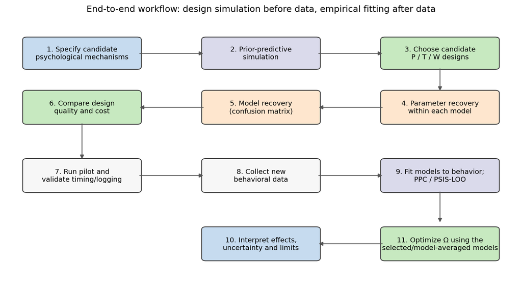

从生成假设到设计优化的完整流程

**优先原则：** 不是把“LOO 最好”或“AIC/BIC 最小”直接宣布为真实心理机制，而是先确保模型能生成合理数据、参数能恢复、不同模型能被区分，随后检查真实数据拟合与样本外预测。若多个模型不可区分，应报告不确定性、优先简约模型或进行预测分布的 stacking，而不是强行宣布唯一赢家（Wilson & Collins, 2019; Ofir & Landau, 2025）。

## 2. 研究问题与总体生成架构

### 2.1 实验设计空间

本项目将设计向量写为：

$$\Omega=(P,T,W,M)$$

- $P$：正式测试之前的额外匹配练习次数（建议命名为 `P_additional_practice_trials`）。
- $T$：形状与标签同时呈现的目标持续时间。
- $W$：从刺激 onset 到最晚可接受反应时刻的**总 response deadline**。
- $M$：如果保留原符号，请在不同语境里明确是 `matching_condition` 还是 `mask_condition`。代码层面建议分别命名为 `is_match` 和 `mask_enabled`。

总体上，把不同变量对应到不同候选心理机制：

$$P\rightarrow\text{association learning / practice adaptation}$$
$$T\rightarrow\text{sensory information availability / encoding}$$
$$W\rightarrow\text{temporal constraint / response policy / urgency}$$
$$\text{Self/Other, Match/Nonmatch}\rightarrow\text{stimulus-related
evidence and response alternatives}$$

然后通过 DDM 生成 response choice 与反应时分布。

### 2.2 为什么采用生成模型，而不是分别拟合 RT 与 accuracy？

DDM 将二选一决策表现建模为带噪声的证据积累过程。它联合约束正确反应 RT、错误反应 RT、反应比例及 RT 分布；相比只拟合均值，多个观测指标会共同限制模型参数（Ratcliff & Rouder, 1998; Ratcliff & McKoon, 2008）。

项目的基本生成链为：

1. 生成被试与试次条件（包括已平衡的刺激配对、被试的练习组、T 与 W）。
2. 根据函数映射获得每个试次的潜在 DDM 参数。
3. 模拟 Wiener 证据过程并确定首次触及边界的时间和方向，或根据相应首次通过时间分布抽样。
4. 加入非决策时间 $t_0$，得到观测 RT。
5. 由按键与当前试次的正确答案推导 Accuracy。
6. 若截至 W 仍无有效响应，保存为 timeout/no-response，而不是丢弃再重抽。
7. 同时另存模拟真值，以便后续参数恢复与模型恢复使用。

### 2.3 证据等级

- **文献支持**：practice 常呈非线性改善；视觉信息的时间整合可能随呈现时间增加而饱和；DDM 的边界可表示谨慎程度；Self-prioritization 在部分 SMT 研究中与信息积累效率和反应偏向均有关。
- **本研究假设**：P 主要通过联结学习影响 drift；T 先通过编码质量影响 drift；W 主要改变静态谨慎程度或动态 urgency。
- **待检验选择**：以上映射具体是否为指数函数，P/T 是否调节 Self–Other 差异，动态边界是否胜过静态边界。

## 3. DDM 参数、选择编码与 SPE 的定义

### 3.1 基本扩散过程

标准 Wiener diffusion process 可写为：

$$dX_t=v\,dt+\sigma\,dB_t$$

其中：

- $X_t$：潜在决策变量；
- $v$：有符号 drift rate；
- $\sigma$：扩散噪声尺度；
- $B_t$：标准 Wiener 过程。

通常将 $\sigma=1$ 固定以设定模型尺度。若同时任意估计 $v,a,\sigma$ 的绝对尺度，参数可能无法被单独识别。$v$ 不是现实空间中以 m/s 表示的物理速度，而是潜在一维决策轴上的平均有符号漂移率。

- $v>0$：平均证据朝定义的上边界漂移。
- $v<0$：平均证据朝定义的下边界漂移。
- $|v|$ 越大，通常意味着证据更有效地支持某一方向，但具体的 RT/accuracy 仍取决于 $a,z,t_0$、扩散尺度及 stimulus coding。

### 3.2 DDM 参数的不同心理含义

| 参数 | 基本含义 | 常见操作解释 | 本项目第一版 |
| --- | --- | --- | --- |
| $v$ | 单位时间的有符号平均证据积累率 | 信息积累效率、证据支持方向 | P/T 与 Self/Other 的主假设作用位置 |
| $a$ | 上下决策边界间距 | response caution；一般较大时更慢、更准确 | W 的静态/动态候选作用位置 |
| $z$ | 初始证据位置 | 反应前偏向 / 起点偏向 | 暂固定中心起点，不额外估计 |
| $t_0$ | 非决策时间 | 编码以外的延迟与运动响应等；标准模型中加到决策时间上 | 固定或由外部证据设定为合理值，后续可扩展 |

参数机制不可直接互换。例如，$v$ 增加可能同时加快 RT 和提升 accuracy；降低 $a$ 也可能加快 RT，但通常伴随准确率下降。两者的预测分布并不相同（Ratcliff & Rouder, 1998; Ratcliff, 2002）。

### 3.3 本项目暂用的 response coding

为减少初版工作量，建议以**反应编码（response coding）**为主：

- 上边界：Match response；
- 下边界：Nonmatch response；
- 当前试次的正确答案由 shape–label 配对规则决定；
- drift 的方向反映证据偏向 Match 还是 Nonmatch；
- 起点位于中心，代表第一版不预设 Match/Nonmatch 的先验反应偏向。

若用上下边界 $0$ 与 $a$，第一版设绝对起点 $z=a/2$，等价于相对起点比例 $z_r=z/a=0.5$。

**术语提醒：** 前面讨论中“方案 A”指“上边界 Match、下边界 Nonmatch”的固定 response-coded 表示法。严格说，它不一定等同于软件包文档中名为 `stimulus coding` 的特定实现选项。不同编码在把边界、漂移符号、起点及条件标签**一致转换**时，可以表达等价的行为模型；但若只改变响应列或把正负 drift 机械交换，而没有同步转换模型参数/先验/回归结构，就不保证拟合等价。开发者必须在实际使用的工具包内验证编码约定。

### 3.4 为什么不把 Self 直接映射到一个固定边界？

Self/Other 是刺激标签或关联属性；Match/Nonmatch 是被试需要作出的反应。两者不是同一分类维度。对于 2 个形状与 2 个标签的 SMT，Self 标签既会出现在匹配试次，也会出现在不匹配试次；同样，Other 标签也可能出现在两类反应要求中。

因此，不能简单令“Self = 上边界”或“Other = 下边界”。固定 response coding 后，Self-related processing 可以通过 drift 的条件差异体现，而中心起点则暂时不表示 Self-specific 起点偏向。

### 3.5 SPE 的候选定义

外显层面：

$$SPE_{RT}=RT_{Other}-RT_{Self}$$
$$SPE_{ACC}=ACC_{Self}-ACC_{Other}$$

潜在证据积累层面，可以比较在**正确反应方向上**的 drift magnitude：

$$\Delta d_{SPE}=d_{Self}-d_{Other}$$

其中 $d$ 是按试次正确反应方向对 drift 有符号量进行对齐后得到的量，而不是直接把原始带符号的 $v$ 在 Match、Nonmatch 混合试次上随意平均。

建议在后续模型中至少区分两个解释：

1. **一般加工效率模型**：P/T 对 Self 与 Other 的影响相同；基础 SPE 可以存在，但不随 P/T 改变。
2. **SPE 调节模型**：P/T 与 Self/Other 有交互，对两类刺激的 drift magnitude 产生不同影响。

与 SMT 直接相关的研究表明，自我优先化可能与更高的信息摄取率相关；部分 DDM 分析也发现 Match response bias / starting-point bias 的作用，说明 SPE 不宜在理论上预先锁定为单一参数（Sui et al., 2012; Golubickis et al., 2017; Svensson et al., 2022; Jalalian et al., 2023, 2024）。

## 4. P：练习次数的数学形式

### 4.1 理论出发点

传统练习定律常讨论幂律改善（Newell & Rosenbloom, 1981; Anderson, 1982），而在个体层级数据上，指数函数也被提出作为练习—RT 关系的重要候选（Heathcote et al., 2000）。群体平均还可能改变所观察到的曲线形状（Murre & Chessa, 2011）。确有任务观察到 S 形学习曲线，但其出现可能依赖材料熟悉程度、学习者差异和学习阶段（Murre, 2014）；策略转换还可能造成学习曲线的局部突变（Delaney et al., 1998）。因此，S 型不能仅凭“练习后表现变好”推出。

### 4.2 第一版：无延迟的指数饱和

先定义归一化练习函数：

$$\boxed{f_P(P)=1-e^{-P/\tau_P}},\qquad \tau_P>0$$

性质：

$$f_P(0)=0,\quad \lim_{P\to\infty}f_P(P)=1$$

其一阶导数为正、二阶导数为负：练习效应随 P 增加而上升，但边际增益逐渐减少。

把它映射到证据积累效率：

$$\boxed{d_P(P)=d_0+\beta_P f_P(P)}$$

其中 $d_0$ 为基线 drift magnitude，$\beta_P$ 为练习可带来的最大增量，$\tau_P$ 为学习时间尺度。第一版不增加延迟参数，遵循简约原则。

另一种等价的写法是：

$$V_P(P)=V_\infty-(V_\infty-V_{initial})e^{-rP}$$

它强调从初值向渐近值靠近。两种表达形式的差别主要在参数命名/参数化，而不是基本曲线家族。

### 4.3 后续竞争模型（不作为第一版前提）

**延迟指数：**

$$f_{P,delay}(P)=1-\exp\left[-\frac{\max(P-P_{delay},0)}{\tau_P}\right]$$

此模型假定 $P\le P_{delay}$ 阶段没有额外练习增量，只有超过延迟点后才开始改善。除非理论或数据支持“早期平台”，不先增加该参数。

其他竞争函数可包括：

$$f_{P,power}(P)=1-(1+P/c)^{-b}$$

或 logistic/Sigmoid，以及分段/变点模型。它们应在生成数据能否被恢复、不同函数是否可区分后再考虑。

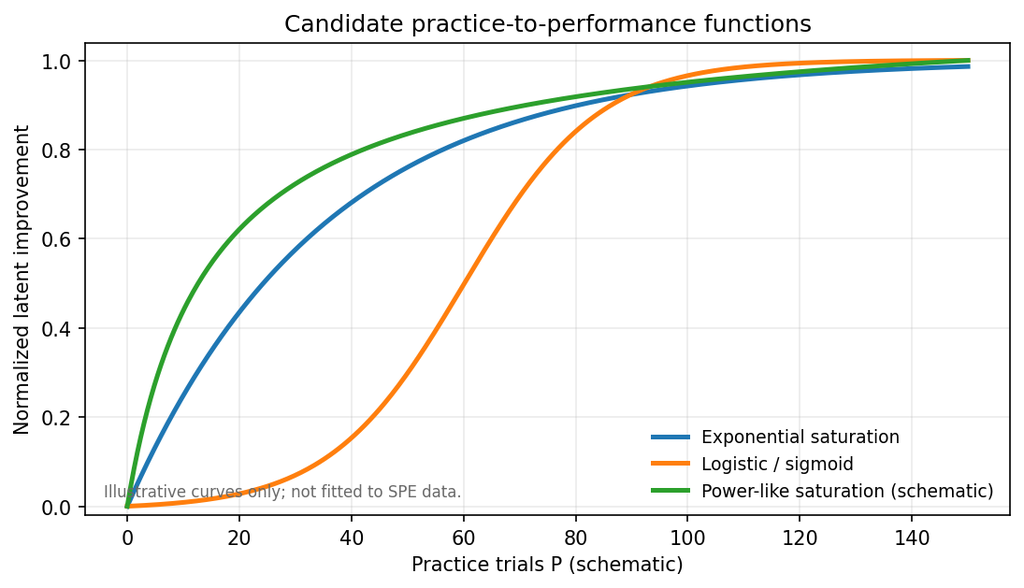

不同练习函数的示意图

**图 1 注释：** 函数图仅用于比较曲线形状；没有哪条曲线是由本项目真实数据拟合得到的。若正式实验中 P 只有两个水平，则无法充分识别连续学习曲线的弯曲程度或 $\tau_P$。

### 4.4 P 的操作性定义必须写清楚

当前 MATLAB 程序所有被试在练习试次前均有固定 60 秒的 shape–label 关联学习阶段。因而 `P = 0` 表示**没有额外匹配练习试次**，并不代表“完全没有接触过联结”。后续模型与文稿应使用 `P_additional_practice_trials` 等名称，避免把它误解为总学习暴露量为零。

如果正式实验阶段还持续产生联结学习，那么 $P$ 的影响不一定在整个正式阶段始终固定。可以预先将 trial index/block 作为另一个时间因素，或在基础模型中说明暂时假设正式阶段没有额外的 P 变化效应。

## 5. T：刺激呈现时间、感觉编码与 drift

### 5.1 机制分层

不把 T 直接映射为 RT 的某个形状，而是先定义可用的视觉信息/编码质量：

$$\boxed{Q_T(T)=1-e^{-T/\tau_T}},\qquad \tau_T>0$$

然后映射到 drift magnitude：

$$\boxed{d_T(T)=d_0+\beta_T Q_T(T)}$$

这表达的是：呈现时间增加，在一定时间范围内可能带来更多可用视觉证据，但额外信息的边际收益可能逐步减小。它是有心理物理与视觉时间整合研究动机的候选模型，并非固定生物学定律（Ratcliff, 2002; Kiani et al., 2008; Deodato & Melcher, 2024; Ketz et al., 2026）。

Bloch’s law 指向非常短刺激时长下，刺激强度和呈现时间在特定范围内的时间总和/互易关系；这可用于支持“时间能影响有效视觉信息”，但不能直接证明 SMT 的编码质量必为指数或 Sigmoid。Stevens (1957) 的心理物理幂律主要针对物理刺激强度到主观感觉量的关系，也不构成“Practice→SPE 必为 Sigmoid”的直接依据。

### 5.2 P 与 T 如何共同影响 drift？

第一版建议从加法结构开始：

$$\boxed{d(P,T)=d_0+\beta_P f_P(P)+\beta_T Q_T(T)}$$

理由不是“数学里所有东西都应该相加”，而是这是一个清晰、参数较少的基线假设：练习与可用视觉信息分别对潜在证据效率提供一个增量。

原代码曾采用乘法及 $1+\alpha$ 放大项。这样的形式不是数学上错误，但它表达的是比例变化/交互约束，需要单独的心理理论理由。旧代码中数值系数 `3` 仅是缩放常数，若未通过扩散尺度与参数化解释，不能直接赋予其心理意义。建议固定 $\sigma=1$，在稳定的尺度下设定可解释的参数范围。

如果后续理论认为 P 与 T 存在交互，可以加入：

$$d(P,T)=d_0+\beta_P f_P(P)+\beta_TQ_T(T)
+\beta_{PT}f_P(P)Q_T(T)$$

但这一项应作为模型竞争的一部分，不是第一版必需成分。

### 5.3 一项重要的时序近似：允许在刺激呈现期间反应

新程序从 stimulus onset 起采集第一次有效按键，且程序目前在记录早期反应后仍继续完成设定的 T 和 mask 阶段，然后进入反馈。因此：

- **刺激实际持续时间**可能仍然约为设定 T（但目前读取 mask 文件的延迟会延长实际时长，见第 8 节）；
- **决策/按键发生时间**可能早于 T；
- 如果生成模型从试次一开始就直接采用“完整 T 对应的最终编码质量”来设定恒定 drift，那么对 $RT<T$ 的试次，它相当于假定编码质量提前达到最终值。

这是一项可接受但需要明示的简化。建议先用修正后的程序开展小规模技术试测，估计 $RT<T$ 的比例；若其很低，可先采用恒定 $d_T(T)$ 的基线。若其较高，则需要后续考虑时间变化输入，例如：

$$Q(t)=Q_{max}(1-e^{-t/\tau_T}),\quad 0\le t\le T$$

刺激消失后是否保持已形成的表征、如何处理遮罩对后续信息的影响，也应成为另一个明确的模型假设，不能默认只有一个答案。

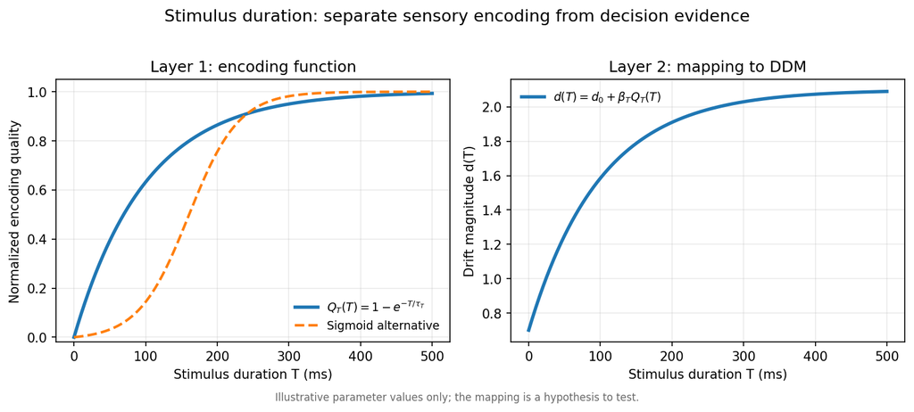

T 到编码质量再到 drift 的函数示意图

**图 2 注释：** 左图显示候选编码函数；右图显示其经过线性映射后的 drift magnitude。它们是两个不同层次的映射。

## 6. W：总反应期限、静态边界与动态边界

### 6.1 操作性定义

本项目已选定：

$$\boxed{W=\text{从 stimulus onset 到 response deadline 的总时间}}$$

刺激呈现时间 T 是 W 内一个独立设定的事件时长，不再把 W 解释为刺激结束后的剩余时长。刺激结束后的时间是一个派生量，不是与 T 完全无关的第三个因素：

$$W-T$$

若刺激后还有固定的 mask/blank 段时长 $T_m=200\,ms$，则空白响应阶段剩余时长约为：

$$W-T-T_m$$

当前程序要求 $W>T+T_m$。实际呈现时间还须依赖屏幕刷新与程序延迟，不能只看名义参数。

### 6.2 W 为什么会影响 a？

较短 deadline 会增加延迟响应的成本，可能使被试采用更快、更不谨慎的 response policy；较长 deadline 可能允许更谨慎的决策。Boundary separation $a$ 是经典 DDM 的 response caution 参数之一（Ratcliff & Rouder, 1998; Ratcliff, 2002; Bogacz et al., 2006; Simen et al., 2009）。但这并不意味着 W 必然以某个固定函数影响 a，也不能仅凭 deadline 就证明存在主观“动机”改变。文稿优先用 response policy、temporal constraint、urgency 和 speed–accuracy trade-off 等术语。

### 6.3 W 模型 W0：固定边界、不让 W 改变边界

建议额外保留一个诊断性模型：

$$a(W)=a_0$$

W 只通过观测 deadline 限制可见 RT/choice，而没有预先改变静态 boundary。这能帮助区分“W 仅截断数据”与“被试策略确实随 W 改变”两种解释。

### 6.4 W 模型 W1：静态指数边界（静态基线）

$$\boxed{a(W)=A_{min}+(A_{max}-A_{min})(1-e^{-W/\tau_a})}$$

这意味着 W 在试次开始时决定一个固定阈值；在单个试次内边界不再变化。

- $A_{min}>0$：最短期限下的边界下限；
- $A_{max}>A_{min}$：宽松期限下可达到的渐近边界；
- $\tau_a>0$：边界对 deadline 的饱和时间尺度。

这里“W 增加，a 增加”是当前需要检验的假设，而不是一般定律。实际结果可能支持无 W effect、反方向或更复杂的动态策略。

### 6.5 W 模型 W2：动态、对称收缩边界（机制性竞争模型）

用户倾向的动态公式可改为带正下限的候选：

$$\boxed{a(s;W)=A_{min}+(A_0-A_{min})
\left[1-\left(\frac{s}{W-t_0}\right)^\Gamma\right]}$$

其中：

- $s$ 是 DDM 决策时钟上的经过时间；
- W 是从 stimulus onset 计时的总 deadline；
- 在标准“观测 RT = decision time + $t_0$”参数化下，decision time 可用的时限为 $W-t_0$，前提是 $W>t_0$；
- $A_0>A_{min}>0$；
- $\Gamma>0$ 控制边界收缩形状。

为了避免下边界固定为零、只降低上边界而引入中心移动/偏向，第一版动态模型建议用**对称收缩边界**。若以中心为原点，可用：

$$L(s)=-a(s;W)/2,\quad U(s)=+a(s;W)/2,\quad X_0=0$$

这与常见 $0$ 到 $a$ 的边界表示在正确平移与转换下对应中心起点。动态边界是一个候选 urgency/deadline 机制；它不是已证实的人类“最优策略”，而且已有研究指出固定边界与 collapsing boundary 的证据取决于任务和数据（Frazier & Yu, 2008; Hawkins et al., 2015; Zhang et al., 2014）。

### 6.6 W 两种主模型的实现难度

| 项目 | W1 静态边界 | W2 动态边界 |
| --- | --- | --- |
| 边界规则 | 单个试次内固定 | 随经过决策时间收缩 |
| 数据生成 | 标准固定边界 WFPT 抽样或路径模拟 | 路径模拟或时变边界数值求解 |
| likelihood | 标准固定边界 WFPT 密度 + deadline 未响应概率 | 匹配的时变边界首次通过时间 likelihood / 数值近似 |
| 实现与诊断 | 相对简单 | 显著更复杂，需验证数值误差 |
| 本项目定位 | 静态基线 | 机制性竞争模型 |

### 6.7 Deadline 下的未响应

若被试直到 W 仍未触及边界，这不是应该重抽的“无效试次”。它是 response deadline 下的 timeout/omission 观测。第一版可以只记录而不建立单独 omission 心理机制，但至少要保存 `responded_by_deadline`、`response_time`、`deadline_W` 和 trial conditions。

在固定边界模型中，响应试次使用响应方向与 RT 的联合密度；超时试次要使用截至期限仍未触及边界的概率，而不能直接从拟合数据中删除。截尾/删失数据的 diffusion modelling 有专门的方法研究（Henrich & Klauer, 2026）。

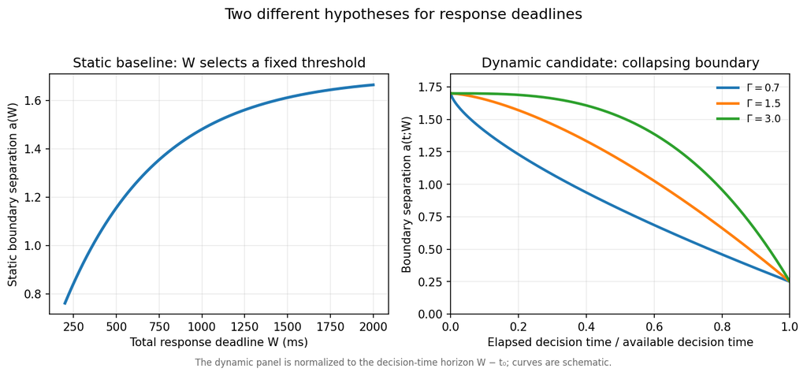

W 的静态与动态边界函数

**图 3 注释：** 左图为 W 到单一静态边界的示意指数饱和；右图为不同 $\Gamma$ 下的动态收缩曲线。数值只用于画图，不是参数估计。

## 7. 生成方法：路径模拟、WFPT 与 deadline 数据

### 7.1 旧 Notebook 使用什么方法？

上传的 `S2 gen_data_jh.ipynb` 是离散时间的 Wiener diffusion path simulation（Euler–Maruyama 风格的离散路径近似）：每一步更新 drift 项与高斯噪声，检查证据是否到达上下边界，然后记录首次触及时间和反应方向。旧代码使用 $\Delta t=0.001\,s$，并用 $z=a/2$ 的中心起点。

它不是直接由 WFPT 密度产生 RT。

### 7.2 Path simulation 与 WFPT 的区别

- **Wiener path simulation**：直接模拟潜在证据路径，直到首次触及边界。灵活，便于实现时变 drift、时变 boundary、复杂时序；但离散步长可能造成穿越边界的时间偏差，且大量试次成本较高。
- **WFPT（Wiener first-passage-time density）**：是固定参数 Wiener 扩散模型首次触及边界的时间密度。固定边界、恒定 drift 的标准 DDM 可以用该密度计算 likelihood，并可用适当的抽样算法直接抽样首次通过时间。Navarro 和 Fuss (2009) 讨论了高效、准确计算该密度的办法。
- **术语限制**：WFPT 是分布/密度，不是另一种心理机制。所谓“用 WFPT 生成数据”，具体可以是“从对应首次通过时间分布抽样”；所谓“WFPT likelihood”则指以该密度计算观测数据 likelihood。
- **动态边界**：普通固定边界 WFPT 不能不经修改就直接用于 $a(t;W)$。动态边界可用数值方法求解，但生成和拟合都要匹配同一套边界定义（Zhang et al., 2014）。

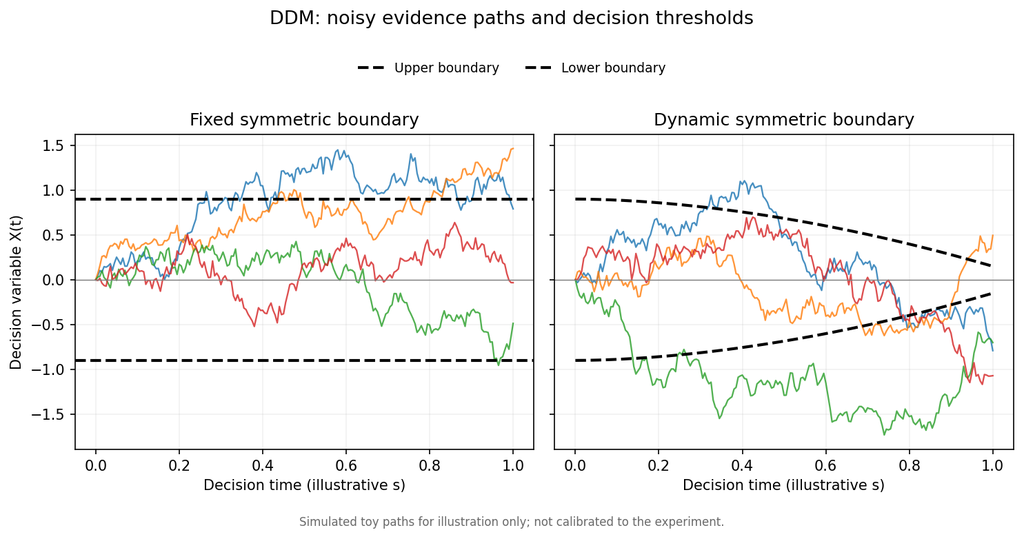

固定边界与动态边界下的示意证据轨迹

### 7.3 生成模型要保存的两份数据

**观测试次文件 `simulated_trials.csv`：**

- `subject_id`, `trial_id`, `block`, `stage`
- `P_additional_practice_trials`, `T_ms`, `W_total_ms`
- `shape`, `label`, `association_type`, `match_condition`
- `correct_response`, `response`, `accuracy`
- `RT_sec`, `responded_by_deadline`, `timeout`
- `mask_enabled`, `stimulus_onset_actual`, `stimulus_offset_actual`, `mask_onset_actual`
- `generator_model_id`, `random_seed`, 以及必要的仿真元数据

**真值文件 `simulation_truth.csv/json`：**

- 被试层级：真实层级参数、随机效应、起点/边界配置等；
- 试次层级：真实 `v` 或 `d`、`a`/`a(t)`、`z`、`t0`、边界首次通过时间与方向（如可获得）；
- 生成模型标识与参数值；
- 随机种子和软件版本。

拟合代码必须只读取观测数据文件，不能将 `simulation_truth` 中的真实参数当作拟合输入。真值文件仅用于参数恢复和模型恢复。

## 8. 第一批数据与 MATLAB 程序审计

### 8.1 第一批数据的组别结构（按对话中提供的表格）

| 组别 | P | T (ms) | 旧版刺激后窗口 $W_{post}$ (ms) | $T+W_{post}$ (ms) | N |
| --- | --- | --- | --- | --- | --- |
| G1 | 0 | 30 | 300 | 330 | 11 |
| G2 | 0 | 30 | 600 | 630 | 12 |
| G3 | 120 | 30 | 600 | 630 | 10 |
| G4 | 120 | 80 | 600 | 680 | 11 |
| G5 | 8 | 100 | 1100 | 1200 | 11 |
| G6 | 120 | 500 | 1500 | 2000 | 10 |
| G7 | 120 | 30 | 800 | **830** | 12 |
| G8 | 120 | 80 | 800 | 880 | 11 |

**核查事项：** 对话中的数据表把 G7 最大允许时间写为 880 ms，但 $30+800=830$ ms。应以实际配置文件和原始日志为准，不能静默地把一个数值更正成另一个。

另一个来源版本差异：旧 MATLAB 程序 `experiment_formal_newcon.m` 的条件表包含第 7 行 `P=0, T=100ms, W=1100ms`，注释称其为程序崩溃后继续实验的应急条件；更新版 `Exp_Design_Formal.m` 则把组 7 改为 `P=8, T=100ms, W=1100ms, mask_enabled=0` 的无掩蔽对照。因而，历史数据表的 G7 与不同版本程序中的 Group 7 不可直接视为同一配置；应根据每名被试的真实文件和程序版本重建设计编码。

### 8.2 旧数据哪些仍然有价值？

旧数据不需要因为程序问题而一概删除，但应将用途分层：

1. 描述性分析：分条件检查 accuracy、已记录 RT 分布、可观测的 timeout/漏答与数据质量；
2. 探索性对比：如 G1/G2（旧窗口）、G2/G3（P）、G3/G4 与 G7/G8（T 的部分比较）等；
3. 模拟参数范围：仅提供粗略量级参考，不能把旧程序产生的偏差数据拟合所得参数当成已知真值；
4. 主确认性 DDM：优先使用修正新程序采集的数据。只有在可以准确描述旧程序的漏记/截尾机制时，才考虑建立专门的观测机制模型并联合处理旧数据。

G1–G2 的 P、T 固定但旧窗口变化；G2–G3 的 T 与旧窗口相同但 P 不同，是较清楚的 P 对比。T 对比（G3–G4、G7–G8）也同时改变总期限 $T+W_{post}$，因此不能视作控制总期限后的纯 T 操纵。G5、G6 没有直接匹配的组别对照，更适合探索性使用。

### 8.3 旧程序的问题

旧版响应读取发生在刺激呈现及 mask 结束之后。早期按键可能漏记或被晚读，形成与真实首次反应时间不同的记录。这类机制既可能导致漏反应，也可能造成 RT 延迟，不能通过简单删除某个 RT 阈值下的记录完整修复。

### 8.4 新程序的改进与剩余技术风险

`Exp_Design_Formal.m` 已实现以下改动：

- W 定义为 onset-to-deadline；
- 刺激期、mask 阶段和后续空白阶段都在轮询 `f/j`；
- 首次有效按键按 stimulus onset 计时；
- 漏答可以保存为未响应而不是错误反应；
- 新程序包含固定的 200 ms mask/blank 阶段；
- 正式阶段 10 个 block × 52 个试次，共 520 个正式试次。

仍需修正/验证：

1. **mask 文件与纹理仍在刺激呈现结束后读取/创建。** `imread` 和 `Screen('MakeTexture')` 可能使刺激实际 offset 晚于名义 T。应预加载纹理，减少关键时段的文件 I/O，并保存实际 stimulus onset/offset 时间戳。
2. 程序使用高频 `KbCheck` 轮询，可能漏掉轮询之间极短的按键事件。建议评估 Psychtoolbox keyboard queue (`KbQueue`) 的时间戳机制，并在每试次清理事件、正确管理按键释放状态。
3. 从 stimulus onset 到 W 的截止时刻必须一致；不要将旧 Wpost 与新 Wtotal 混用。
4. 主实验应统一 mask 状态，除非掩蔽本身是明确研究因素。现版组 5 与组 7 的 P/T/W 相同但 mask 状态不同，可构成探索性掩蔽对比，却不能与其余组混作单一条件效应而忽略掩蔽。
5. 试次期间记录到早期按键后，程序仍继续显示剩余 T 和 mask；因此按键发生时的行为进程与最终物理显示持续时间不同。模拟模型应清楚表达这一规则。
6. 要确保 `Correct`、`Response`、`RT`、timeout 字段缺失值在文件中稳定表示为 NaN/NA，而不是被格式化为字面字符串或错误的零。
7. 如果显示器刷新率为 60 Hz，名义的 30 ms 不对应整数帧（约 1.8 帧）；代码按 `round(T / FlipIntv)` 变成离散帧数。因此应根据实际刷新率选择帧数可实现的 T 水平，并在输出中保存目标时长和实际时长。

建议的 trial timeline：

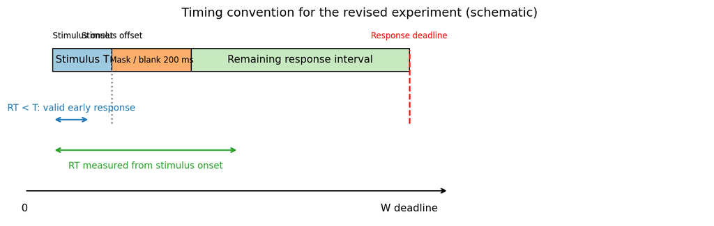

W 从 stimulus onset 起算的试次时间轴

## 9. 正式数据收集的候选设计

### 9.1 设计原则

不先凭经验宣布 2×2×2 或 3×3×3 必然最优。二水平全因子有利于主效应与交互效应筛选，但只有两个水平通常不足以可靠估计指数/幂函数的时间常数或曲线弯曲形状。多水平设计也并不自动保证可恢复；需要通过候选模型的 parameter recovery 和 model recovery 决定。

建议的初始结构为**混合因子设计**：

- P：被试间因素，代表正式实验前额外练习量；
- T：被试内因素；
- W：被试内因素，但 deadline 应当在被试作答前可知（可在 block 开始时提示），以便合理检验 response policy 是否随 W 调整；
- Self/Other × Match/Nonmatch：在每个 T × W cell 中平衡；
- stimulus-shape 配对、正确键映射、block 顺序和手指/按键优势需在被试间平衡。

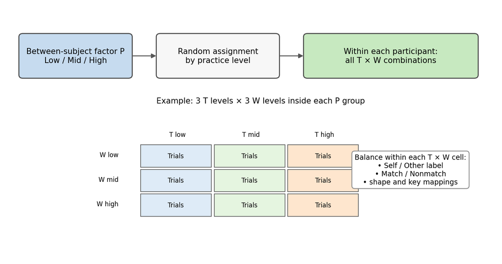

混合因子设计结构示意图

### 9.2 候选设计 A：2×2×2，低成本筛选

- P：0、120 次；
- T：30、150 ms；
- W：600、1200 ms；
- P 为被试间；T×W 为被试内，共 4 个 T×W cell；
- 如果每个 T×W cell 的四个刺激子条件（Self/Other × Match/Nonmatch）各重复 16 次，则每人正式试次为 $4\times4\times16=256$。

优点：负担较低，适合筛查端点效应与较大的交互。局限：难以充分识别 P/T/W 的非线性曲线，不能仅凭该设计认真裁定指数与 Sigmoid 的形状差异。

### 9.3 候选设计 B：3×3×3 或折中设计（优先进入模拟比较）

一个折中候选：

- P：0、8、32、120（四个被试间水平；仅为候选集合，非已定最优水平）；
- T：30、80、150 ms；
- W：600、900、1200 ms；
- 每人 9 个 T×W 组合；若每个组合的 4 个刺激子条件各 16 次，则每人 576 个正式试次。

该方案可更好覆盖曲线增长与饱和区，又保留较可控的工作量。P 水平为 4 的倍数以适配现有程序每轮呈现 4 类练习刺激的结构。由于所有被试在正式实验前均经历 60 秒关联学习，P=0 仍有学习暴露。

### 9.4 候选设计 C：更高信息量设计

- P：0、8、32、120；
- T：30、80、150、250 ms；
- W：600、800、1000、1300 ms；
- 每人 16 个 T×W cell；如果每个 cell 的四类刺激各重复 12 次，则每人 768 个正式试次。

优势：T 与 W 的多水平覆盖更有机会区分非线性函数与边界机制。代价：被试疲劳、总实验时长、学习/疲劳混合趋势和超时率的控制压力都会提高。它不是默认优于方案 B，需要 model-recovery 结果证明新增水平带来有效信息。

### 9.5 T/W 条件的物理和行为约束

- 所有条件必须满足 $W>T+T_m$，当前 $T_m=200$ ms；更严格地需检查实际事件时刻。
- 若 W 在同一被试内改变，应通过 block 顺序平衡（例如 Latin/Williams 类平衡次序）减轻 W 条件与 session time 的混淆；T 在 block 内随机平衡。
- W 应在该 block 或试次开始前对被试可知；否则 W 对主观 response policy 的效应可能弱化，而对数据的截断效应仍存在。
- 同一个 T×W cell 必须平衡 Self/Other 与 Match/Nonmatch，也应平衡各形状、身份标签与正确按键。
- 设计中应保留实际按键时间戳、timeout、stimulus offset、mask onset 和 block/trial index，以便检测早期反应、超时和随时间变化的学习/疲劳。

### 9.6 被试数与 trial 数不应该先验拍定

候选方案可以比较每个 P 组 15、25、35 人等多个场景；每位被试 256、576、768 试次也可作为候选模拟版本。它们只是**设计模拟的网格**，不是功效分析已确定的最终招募量。

最终选择应基于：

1. 关键参数的偏差、RMSE 与区间覆盖；
2. 指数 vs. Sigmoid / 静态 vs. 动态边界 / SPE 交互模型的恢复率；
3. deadline timeout 是否过多、条件下是否出现严重极端准确率；
4. 每个被试的时间成本、疲劳和 trial-order 效应；
5. 关键目标量（例如 $\Delta d_{SPE}$）的识别精度。

## 10. 参数恢复、模型恢复与真实数据拟合

### 10.1 没有真实数据可以做恢复吗？

可以。参数恢复和模型恢复的定义本来就是基于已知生成真值的模拟检验。需要先设定一组合理但宽泛的参数范围，可以参考文献、当前程序/任务时间尺度以及旧数据提供的粗略行为范围；旧数据因漏记机制不应被当成无偏真值。建议对多个合理参数区域重复模拟，检验设计结论是否敏感。

恢复模拟能回答“如果某个模型/参数是真的，在本设计的被试数和 trial 数下，我们能否认出它”，不能回答“哪个模型一定是真实心理过程”。后者需要真实数据与模型比较共同支持。

### 10.2 Parameter recovery

对每个候选模型：

1. 从先验/宽参数范围抽取真值 $\theta^{true}$；
2. 按实际候选设计生成多套数据；
3. 使用与候选生成机制匹配的模型重新拟合；
4. 将 $\hat\theta$ 与 $\theta^{true}$ 比较。

报告不应只看相关系数，还应包含：

$$Bias=\mathbb E[\hat\theta-\theta^{true}]$$
$$RMSE=\sqrt{\mathbb E[(\hat\theta-\theta^{true})^2]}$$

以及区间覆盖率、收敛率、参数相关/补偿、关键效应的符号恢复概率。重点参数包括 $\tau_P,\tau_T,\tau_a,\Gamma,\beta_S,\beta_{SP},\beta_{ST}$ 等；第一版不要一次性全部放入同一个复杂模型，而要按阶段增加。

### 10.3 Model recovery

对每个模型作为生成模型分别生成许多套数据，然后将每一套数据分别拟合所有候选模型，统计最终模型选择结果，构建 confusion matrix。矩阵对角线越高，说明该生成机制较常被正确识别；非对角线揭示哪些模型互相混淆。

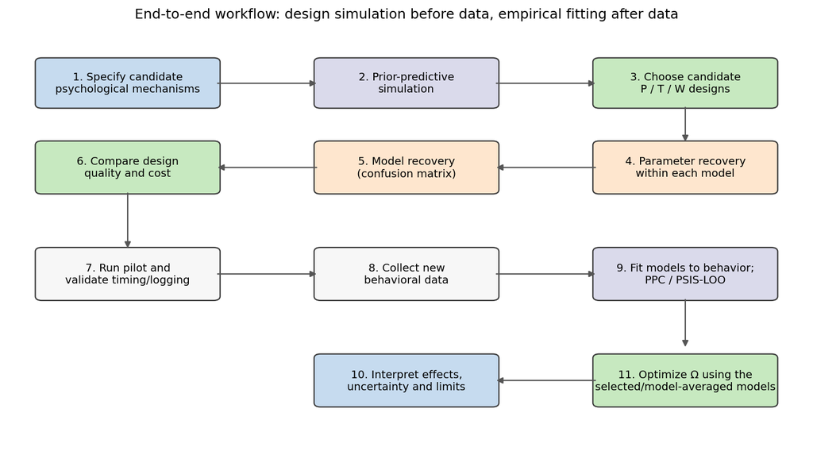

建模流程图

Ofir 和 Landau (2025) 的 temporal generalization DDM 工作可作为验证工作流的范例：它包含参数恢复、模型恢复以及对真实行为的模型拟合。但其任务的证据变量和反应结构与 SMT + response deadline 不同，因此可借鉴验证逻辑，不能照搬其参数解释或试次数要求。

### 10.4 真实数据的 model fitting

设计方案通过恢复模拟筛选、程序验证后，才开展主实验并对真实数据拟合。建议使用 trial-level RT + choice 的联合模型，而不是只对条件平均 RT/accuracy 做曲线拟合。

- 固定边界模型：可使用标准 WFPT likelihood，并使用 deadline 适配的未响应概率。
- 动态边界模型：使用动态边界首次通过时间的数值解或经过验证的 likelihood；不能用静态 WFPT density 直接冒充。
- 层级模型：可用 participant-level varying parameters/regression，避免只拟合一个群体均值（Vandekerckhove et al., 2011; Wiecki et al., 2013; Boehm et al., 2018）。

### 10.5 Posterior predictive checks（PPC）

模型拟合后，从 posterior predictive distribution 重新生成 RT、choice 和 timeout，并按原设计条件比较真实数据与预测。至少检查：

- 正确与错误 RT 的分位数（例如 .1、.3、.5、.7、.9）和分布形状；
- 正确率/错误率；
- RT 与 accuracy 的联合模式；
- Self/Other × Match/Nonmatch 的条件模式；
- $SPE_{RT}$、$SPE_{ACC}$ 与潜在 $\Delta d_{SPE}$ 的可预测后果；
- P/T/W 条件趋势、block/trial order 趋势、deadline timeout 比例。

只重现平均 RT 不足以验证一个 DDM，因为不同参数组合可能产生相似的均值，却有不同的 RT 分布和错误模式（Ratcliff & Rouder, 1998; Gabry et al., 2019）。

### 10.6 预测模型比较

对于 Bayesian hierarchical 模型，建议把 PSIS-LOO 的 ELPD 作为主要样本外预测比较指标之一，同时检查 Pareto $k$ 诊断和 $\Delta ELPD$ 标准误（Vehtari et al., 2017, 2024）。WAIC 可作辅助；AIC/BIC 可用于适用的最大似然模型，但不应随意与不同 likelihood/不同观测单位的结果混比。

如果模型的预测差异相对于不确定度很小，不能强行宣布唯一赢家。可选择更简约、理论更明确的模型；或者用 stacking 加权组合预测分布，再做模型平均的设计优化（Yao et al., 2018）。Bayes factor 能比较边际似然，但可能对先验敏感；若采用，需做 prior sensitivity，并选择适用于证据积累模型的方法（Gronau et al., 2020）。

**重要：** trial-level LOO 通常更接近对同一个被试的遗漏 trial 做预测；若目标是泛化到新被试，则需用 participant-level K-fold/leave-one-participant-out，不能让同一被试的数据同时泄漏到训练和测试折中。

### 10.7 最优设计不是“条件最多的设计”

对候选设计 $\Omega$，选择规则应综合：

- 关键参数可恢复程度；
- 模型机制可区分程度；
- 对 reasonable parameter ranges 的鲁棒性；
- timeout 与疲劳负担；
- 预期的 SPE 量估计精度；
- 实验实施可行性。

如果多个模型无法可靠区分，可以在可接受模型集合上进行 model-averaged design utility：

$$U(\Omega)=\sum_m w_m U_m(\Omega)$$

其中 $w_m$ 可来自 stacking 或另一个事先声明的方法。这会使最终设计对心理机制不确定性更鲁棒，而不是只在单一假设下“最优”。

## 11. 模型候选集合与分阶段比较计划

为了避免一下子形成过多交叉模型，推荐按以下顺序逐步比较。

### 阶段 A：基础模拟器正确性

- 静态边界、恒定 drift、中心起点、固定 $t_0$；
- 验证 RT/choice 是否符合标准 DDM 预期；
- 若采用 path simulation，将不同 $\Delta t$ 的结果与固定边界 WFPT 进行对比，检查时间步长偏差；
- 验证 deadline 下 timeout 概率计算正确。

### 阶段 B：P/T 映射

- P：标准指数饱和 vs. legacy Sigmoid（以及必要时 power/linear）；
- T：指数编码饱和 vs. 一种预先指定的替代函数；
- 先保持 W 边界简单，不要同时改变太多机制。

### 阶段 C：W 边界机制

- W0：固定 $a$，仅外部 deadline；
- W1：静态 $a(W)$ 指数饱和；
- W2：动态对称 collapsing boundary $a(s;W)$。

### 阶段 D：SPE 机制

- G0：P/T 影响一般 drift，Self–Other 差异不随 P/T 变化；
- G1：加入 P × Self；
- G2：加入 T × Self；
- G3：两种调节都加入。

若没有足够证据，可先不估计 Self-specific $z$；之后若导师要求研究响应偏向，再让 $z$ 随 stimulus/response condition 变化，并通过 recovery 检验。

### 阶段 E：真实数据拟合和 model selection

所有候选模型使用同一套符合规则的 trial-level 数据、同一明确的数据排除标准和可比较的 prior/predictive evaluation。若某模型不收敛、关键参数不可恢复、PPC 明显失败或 deadline likelihood 错误，不能只因为它的某个信息准则较低就入选。

## 12. 建议的实施顺序与风险清单

### 12.1 当前推荐的执行顺序

1. **程序技术验证**：预加载 mask；记录真实 flip 时间；验证 keyboard event time；核实条件表、实际帧数、RT 起点和 W deadline；
2. **建立最小静态 DDM 生成器**：固定 $\sigma$，中心起点、恒定 drift、固定边界，验证 Choice/RT 分布；
3. **实现 P 与 T 的函数映射**：用清楚命名的参数、宽合理范围；先不加延迟、交互或自我起点偏向；
4. **实现 W0/W1**：固定边界与静态指数边界，加入 deadline 未响应概率；
5. **再实现 W2**：确定时变边界 likelihood/数值求解器；对生成和拟合进行数值正确性检查；
6. **运行 prior predictive 与参数恢复**；
7. **对候选模型做 model recovery**；
8. **比较 2×2×2、3×3×3 与高信息量设计，决定 P/T/W 以及样本规模**；
9. **完成小规模 pilot 并检查实际 RT、早期反应、timeout、刺激呈现时长**；
10. **正式数据收集**；
11. **Fitting the model to behavior + PPC + PSIS-LOO/模型比较**；
12. **把最可靠的模型或模型集合用于设计空间优化**。

### 12.2 风险清单

| 风险 | 为什么重要 | 缓解办法 |
| --- | --- | --- |
| 旧/新 W 定义混用 | deadline 与 RT 分布不同 | 旧数据使用 `W_post`，新数据使用 `W_total`，不要混列 |
| stimulus offset 被 mask 读取拖延 | 名义 T 与真实 T 不同 | 预加载图像/texture，记录 flip timestamps |
| 仅保存有反应试次 | timeout likelihood 无法建立 | 每试次都记录是否响应与截止时间 |
| 直接把 Self 映射到某个边界 | Self 与 Match 不等同 | 统一 response coding，Self-specific effect 先进入 drift magnitude |
| 用完整 T 的 Q(T) 解释 T 前的 response | 暗含瞬时达到完整编码 | 先估早期反应比例；必要时发展时间变化输入模型 |
| 只看模型的 LOO winner | 预测优势不等于心理机制可识别 | 参数恢复、模型恢复、PPC 和预测比较都通过后才解释 |
| P 太少的水平 | 非线性时间常数可能不可识别 | 通过设计模拟选水平，而非只用高/低两个点 |
| 复杂模型太多 | Recovery 命中率可能低、参数补偿 | 按阶段增复杂度，逐步加入交互/时变边界 |
| 所有被试都按同一 block 顺序 | W 与 trial time/练习趋势混淆 | 平衡 block 顺序并记录 trial/block index |
| 只拟合均值 RT | 忽略错误 RT 与分布尾部 | RT + choice 联合拟合并做 PPC |

### 12.3 最终研究立场

本项目并不是先证明“所有变量都服从某种特定曲线”，再把曲线塞进 DDM。更可靠的路线是：为 P、T、W 各自提出有心理解释的可计算映射；让候选机制生成可观察的 RT/choice/timeout 分布；用参数恢复和模型恢复评估设计是否有能力识别机制；再用新实验数据检验模型是否能解释真实行为。

这个框架能够允许结果是：指数比 Sigmoid 更稳健、静态边界已足够、某些交互不需要、或者当前设计不能区分两种模型。上述任何一种都可能是有价值的实证结果。

## 13. 参考文献（APA 7）

以下收录本次讨论中实质使用或此前回答已提到的主要理论、方法与 SMT 研究。DOI 优先以 DOI 链接提供。文献的证据角色不一样：有的是一般学习曲线依据，有的是一般视觉时间整合，有的是 DDM 方法，还有的是直接 SMT 证据。不要把相邻任务的结果当作对本研究特定函数的直接证明。

### 13.1 Practice 与学习曲线

Anderson, J. R. (1982). Acquisition of cognitive skill. *Psychological Review, 89*(4), 369–406. https://doi.org/10.1037/0033-295X.89.4.369

Delaney, P. F., Reder, L. M., Staszewski, J. J., & Ritter, F. E. (1998). The strategy-specific nature of improvement: The power law applies by strategy within task. *Psychological Science, 9*(1), 1–7. https://doi.org/10.1111/1467-9280.00001

Heathcote, A., Brown, S., & Mewhort, D. J. K. (2000). The power law repealed: The case for an exponential law of practice. *Psychonomic Bulletin & Review, 7*(2), 185–207. https://doi.org/10.3758/BF03212979

Leibowitz, N., Baum, B., Enden, G., & Karniel, A. (2010). The exponential learning equation as a function of successful trials results in sigmoid performance. *Journal of Mathematical Psychology, 54*(3), 338–340. https://doi.org/10.1016/j.jmp.2010.01.006

Murre, J. M. J. (2014). S-shaped learning curves. *Psychonomic Bulletin & Review, 21*(2), 344–356. https://doi.org/10.3758/s13423-013-0522-0

Murre, J. M. J., & Chessa, A. G. (2011). Power laws from individual differences in learning and forgetting: Mathematical analyses. *Psychonomic Bulletin & Review, 18*(3), 592–597. https://doi.org/10.3758/s13423-011-0076-y

Newell, A., & Rosenbloom, P. S. (1981). Mechanisms of skill acquisition and the law of practice. In J. R. Anderson (Ed.), *Cognitive skills and their acquisition* (pp. 1–51). Lawrence Erlbaum Associates.

### 13.2 Visual encoding、temporal integration 与 T

Deodato, M., & Melcher, D. (2024). Continuous temporal integration in the human visual system. *Journal of Vision, 24*(13), Article 5. https://doi.org/10.1167/jov.24.13.5

Ketz, C. C., Bach, M., & Heinrich, S. P. (2026). Landolt C acuity follows Bloch’s law for short-duration flashes. *Frontiers in Neuroscience, 20*, Article 1954783. https://doi.org/10.3389/fnins.2026.1954783

Eckhoff, P., Holmes, P., Law, C., Connolly, P. M., & Gold, J. I. (2008). On diffusion processes with variable drift rates as models for decision making during learning. *New Journal of Physics, 10*, Article 015006. https://doi.org/10.1088/1367-2630/10/1/015006

Kiani, R., Hanks, T. D., & Shadlen, M. N. (2008). Bounded integration in parietal cortex underlies decisions even when viewing duration is dictated by the environment. *The Journal of Neuroscience, 28*(12), 3017–3029. https://doi.org/10.1523/JNEUROSCI.4761-07.2008

Ratcliff, R. (2002). A diffusion model account of response time and accuracy in a brightness discrimination task: Fitting real data and failing to fit fake but plausible data. *Psychonomic Bulletin & Review, 9*(2), 278–291. https://doi.org/10.3758/BF03196283

Ratcliff, R. (2014). Measuring psychometric functions with the diffusion model. *Journal of Experimental Psychology: Human Perception and Performance, 40*(2), 870–888. https://doi.org/10.1037/a0034954

Stevens, S. S. (1957). On the psychophysical law. *Psychological Review, 64*(3), 153–181. https://doi.org/10.1037/h0046162

Thorpe, S., Fize, D., & Marlot, C. (1996). Speed of processing in the human visual system. *Nature, 381*, 520–522. https://doi.org/10.1038/381520a0

### 13.3 Self-prioritization / SMT 与条件相关偏差

Golubickis, M., Falben, J. K., Sahraie, A., Visokomogilski, A., Cunningham, W. A., Sui, J., & Macrae, C. N. (2017). Self-prioritization and perceptual matching: The effects of temporal construal. *Memory & Cognition, 45*(7), 1223–1239. https://doi.org/10.3758/s13421-017-0722-3

Golubickis, M., Selvaraj, E. S., Caughey, S., Jalalian, P., Sharma, Y., & Macrae, C. N. (2026). It’s probably mine: Self-prioritization can be a decisional strategy. *Cognitive Science, 50*(3), Article e70190. https://doi.org/10.1111/cogs.70190

Jalalian, P., Golubickis, M., Sharma, Y., & Macrae, C. N. (2023). Electrophysiological correlates of self-prioritization. *Consciousness and Cognition, 108*, Article 103475. https://doi.org/10.1016/j.concog.2023.103475

Jalalian, P., Golubickis, M., Sharma, Y., & Macrae, C. N. (2023). Learning about me and you: Only deterministic stimulus associations elicit self-prioritization. *Consciousness and Cognition, 116*, Article 103602. https://doi.org/10.1016/j.concog.2023.103602

Jalalian, P., Golubickis, M., Sharma, Y., & Macrae, C. N. (2024). The temporal profile of self-prioritization. *Consciousness and Cognition, 125*, Article 103763. https://doi.org/10.1016/j.concog.2024.103763

Jalalian, P., Golubickis, M., Sharma, Y., Kanakraj, R., Selvaraj, E. S., & Macrae, C. N. (2026). Reward value shapes the time course of self-bias. *Memory & Cognition, 54*, 483–500. https://doi.org/10.3758/s13421-025-01763-4

Sui, J., He, X., & Humphreys, G. W. (2012). Perceptual effects of social salience: Evidence from self-prioritization effects on perceptual matching. *Journal of Experimental Psychology: Human Perception and Performance, 38*(5), 1105–1117. https://doi.org/10.1037/a0029792

Svensson, S. L., Golubickis, M., Maclean, H., Falbén, J. K., Cunningham, W. A., Sui, J., & Macrae, C. N. (2022). More or less of me and you: Self-relevance augments the effects of item probability on stimulus prioritization. *Psychological Research, 86*(4), 1145–1164. https://doi.org/10.1007/s00426-021-01562-x

### 13.4 DDM、WFPT、层级模型与 deadline

Bogacz, R., Brown, E., Moehlis, J., Holmes, P., & Cohen, J. D. (2006). The physics of optimal decision making: A formal analysis of models of performance in two-alternative forced-choice tasks. *Psychological Review, 113*(4), 700–765. https://doi.org/10.1037/0033-295X.113.4.700

Frazier, P. I., & Yu, A. J. (2008). Sequential hypothesis testing under stochastic deadlines. In *Advances in Neural Information Processing Systems 20* (pp. 465–472). Curran Associates.

Hawkins, G. E., Forstmann, B. U., Wagenmakers, E.-J., Ratcliff, R., & Brown, S. D. (2015). Revisiting the evidence for collapsing boundaries and urgency signals in perceptual decision-making. *The Journal of Neuroscience, 35*(6), 2476–2484. https://doi.org/10.1523/JNEUROSCI.2410-14.2015

Henrich, F., & Klauer, K. C. (2026). Modeling truncated and censored data with the diffusion model in Stan. *Behavior Research Methods, 58*, Article 42. https://doi.org/10.3758/s13428-025-02822-z

Navarro, D. J., & Fuss, I. G. (2009). Fast and accurate calculations for first-passage times in Wiener diffusion models. *Journal of Mathematical Psychology, 53*(4), 222–230. https://doi.org/10.1016/j.jmp.2009.02.003

Ratcliff, R., & McKoon, G. (2008). The diffusion decision model: Theory and data for two-choice decision tasks. *Neural Computation, 20*(4), 873–922. https://doi.org/10.1162/neco.2008.12-06-420

Ratcliff, R., & Rouder, J. N. (1998). Modeling response times for two-choice decisions. *Psychological Science, 9*(5), 347–356. https://doi.org/10.1111/1467-9280.00067

Ratcliff, R., & Tuerlinckx, F. (2002). Estimating parameters of the diffusion model: Approaches to dealing with contaminant reaction times and parameter variability. *Psychonomic Bulletin & Review, 9*(3), 438–481. https://doi.org/10.3758/BF03196302

Reinhartz, A., Strobach, T., Jacobsen, T., & von Bastian, C. C. (2023). Mechanisms of training-related change in processing speed: A drift-diffusion model approach. *Journal of Cognition, 6*(1), Article 46. https://doi.org/10.5334/joc.310

Simen, P., Contreras, D., Buck, C., Hu, P., Holmes, P., & Cohen, J. D. (2009). Reward rate optimization in two-alternative decision making: Empirical tests of theoretical predictions. *Journal of Experimental Psychology: Human Perception and Performance, 35*(6), 1865–1897. https://doi.org/10.1037/a0016926

Vandekerckhove, J., Tuerlinckx, F., & Lee, M. D. (2011). Hierarchical diffusion models for two-choice response times. *Psychological Methods, 16*(1), 44–62. https://doi.org/10.1037/a0021765

Wiecki, T. V., Sofer, I., & Frank, M. J. (2013). HDDM: Hierarchical Bayesian estimation of the Drift-Diffusion Model in Python. *Frontiers in Neuroinformatics, 7*, Article 14. https://doi.org/10.3389/fninf.2013.00014

Zhang, S., Lee, M. D., Vandekerckhove, J., Maris, G., & Wagenmakers, E.-J. (2014). Time-varying boundaries for diffusion models of decision making and response time. *Frontiers in Psychology, 5*, Article 1364. https://doi.org/10.3389/fpsyg.2014.01364

### 13.5 模型恢复、Bayesian workflow、预测比较与模型平均

Boehm, U., Steingroever, H., & Wagenmakers, E.-J. (2018). Using Bayesian regression to test hypotheses about relationships between parameters and covariates in cognitive models. *Behavior Research Methods, 50*(3), 1248–1269. https://doi.org/10.3758/s13428-017-0940-4

Gabry, J., Simpson, D., Vehtari, A., Betancourt, M., & Gelman, A. (2019). Visualization in Bayesian workflow. *Journal of the Royal Statistical Society: Series A (Statistics in Society), 182*(2), 389–402. https://doi.org/10.1111/rssa.12378

Gronau, Q. F., Heathcote, A., & Matzke, D. (2020). Computing Bayes factors for evidence-accumulation models using Warp-III bridge sampling. *Behavior Research Methods, 52*(2), 918–937. https://doi.org/10.3758/s13428-019-01290-6

Ofir, N., & Landau, A. N. (2025). A drift-diffusion model of temporal generalization outperforms existing models and captures modality differences and learning effects. *Behavior Research Methods, 57*, Article 334. https://doi.org/10.3758/s13428-025-02819-8

Vehtari, A., Gelman, A., & Gabry, J. (2017). Practical Bayesian model evaluation using leave-one-out cross-validation and WAIC. *Statistics and Computing, 27*, 1413–1432. https://doi.org/10.1007/s11222-016-9696-4

Vehtari, A., Simpson, D., Gelman, A., Yao, Y., & Gabry, J. (2024). Pareto smoothed importance sampling. *Journal of Machine Learning Research, 25*(72), 1–58. https://www.jmlr.org/papers/v25/19-556.html

Wilson, R. C., & Collins, A. G. E. (2019). Ten simple rules for the computational modeling of behavioral data. *eLife, 8*, Article e49547. https://doi.org/10.7554/eLife.49547

Yao, Y., Vehtari, A., Simpson, D., & Gelman, A. (2018). Using stacking to average Bayesian predictive distributions (with discussion). *Bayesian Analysis, 13*(3), 917–1007. https://doi.org/10.1214/17-BA1091

### 13.6 建议阅读顺序

1. **总体建模流程**：Wilson & Collins (2019)。
2. **DDM 参数意义、正确与错误 RT**：Ratcliff & Rouder (1998); Ratcliff & McKoon (2008)。
3. **练习函数家族**：Newell & Rosenbloom (1981); Heathcote et al. (2000); Murre (2014); Delaney et al. (1998)。
4. **T 与 drift**：Ratcliff (2002); Kiani et al. (2008); Deodato & Melcher (2024); Ketz et al. (2026)。
5. **Deadline 与动态边界**：Bogacz et al. (2006); Frazier & Yu (2008); Hawkins et al. (2015); Zhang et al. (2014); Henrich & Klauer (2026)。
6. **直接 SMT/SPE 机制**：Sui et al. (2012); Golubickis et al. (2017); Svensson et al. (2022); Jalalian et al. (2024)。
7. **恢复、拟合与模型比较**：Wiecki et al. (2013); Boehm et al. (2018); Gabry et al. (2019); Vehtari et al. (2017); Ofir & Landau (2025); Yao et al. (2018)。

## 附录 A：传递给后续 AI/开发者的最小规格

1. 不改变 $W$ 定义：W 从 stimulus onset 到 deadline。
2. 所有时间单位内部统一为秒；导出文件可同时保存 ms 列。
3. $\sigma=1$；第一版以中心起点 $z_r=0.5$ 为主。
4. P/T 首版函数使用归一化指数饱和，先用加性 drift magnitude。
5. 明确 Match/Nonmatch 与 Self/Other 的条件关系；上边界固定代表 Match response，下边界固定代表 Nonmatch response。
6. P/T 先允许一般加工效率效应；另建候选模型检验其是否调节 Self–Other drift difference。
7. W 的静态指数模型作为基线；动态对称边界作为竞争机制模型。
8. 动态边界不得使用未经修改的固定边界 WFPT likelihood。
9. timeout 不得从数据中删除或反复重抽。
10. 生成的 trial data 与 truth data 分开。
11. 先验证静态模拟器，再验证 P/T 映射，再实现 deadline，再实现动态边界。
12. 每个候选设计都做参数恢复与模型恢复；真实数据阶段做 PPC 与模型比较。
13. 程序输出实际 stimulus flip/offset 与 key timestamp；预加载 mask texture，避免 T 的实际呈现时长被 IO 延迟改变。
14. 新旧程序数据不可在不建模记录机制的前提下简单合并。
15. 所有函数图是候选机制的示意，不是拟合到真实 SPE 数据的结果。

*文档完。*